# Paso 4: Modelo B — Gradient Boosting (LightGBM)

## Por qué gradient boosting y no SARIMA (recapitulación conceptual)

Tu pregunta original era si aplicaba ARIMA/SARIMA. La respuesta corta: SARIMA modela **una** serie temporal continua, y este problema son ~350 series producto-tienda, la mayoría **intermitentes** (días con 0, 1, 2 unidades). ARIMA asume una serie con estructura autorregresiva continua; con demanda intermitente sus supuestos se rompen.

Gradient boosting reformula el problema: en lugar de "continuar una serie", predice `cantidad = f(características del día y del producto)`. Cada fila es una observación independiente descrita por *features*, y el modelo aprende interacciones entre ellas (ej.: "los sábados la familia Viennoiserie vende el doble... pero solo en Sinclair"). Un solo modelo aprende de las 350 series a la vez — los productos flacos de datos se benefician de patrones aprendidos en los gordos. Esto se llama **aprendizaje cruzado (cross-learning)** y es la razón por la que este enfoque ganó las competencias M5 de forecasting retail.

## Las 5 decisiones de diseño de este notebook

1. **La grilla con ceros** — el dataset de ventas solo tiene filas cuando algo se vendió. Si entrenáramos solo con esas filas, el modelo aprendería de un mundo donde "siempre se vende algo" y sobreestimaría sistemáticamente. **La ausencia de venta es información**: construimos la grilla completa producto × tienda × día abierto y rellenamos con 0.
2. **Función de pérdida Poisson** — la cantidad vendida es un *conteo*: entero, no negativo, con muchos ceros. La pérdida cuadrática (MSE) asume ruido simétrico y puede predecir negativos; **Poisson** modela conteos de eventos y es el estándar para demanda. Detalle práctico: hay 11 filas con cantidad negativa (devoluciones netas); las llevamos a 0 porque Poisson exige `y >= 0` y son irrelevantes en volumen.
3. **Features causales** — cada feature debe calcularse **solo con información anterior al día que describe** (por eso el `shift(1)` antes de cada rolling). Si la media móvil de un día incluyera al propio día, el modelo "vería el futuro" (*leakage*): brillaría en el backtest y fallaría en producción. Es el error #1 en forecasting con ML.
4. **Snapshot congelado para predecir** — al presupuestar jul-dic no existirán las ventas de esos meses para calcular medias móviles. Tomamos los valores al último día conocido y los congelamos para todo el horizonte (*direct forecasting* con nivel estático). La alternativa (*recursive*: predecir día 1, usarlo como input del día 2...) acumula error en horizontes largos. Para presupuesto, congelar es lo honesto: el nivel del producto es "el actual".
5. **Mismo protocolo de evaluación que el Modelo A** — parados a fin de abril, predecimos may-jun, mismas métricas, mismo tratamiento del 22/6. Sin esto la comparación no vale nada.

```python
import pandas as pd
import numpy as np
import matplotlib.pyplot as plt

daily = pd.read_parquet('daily.parquet')
maestro = pd.read_parquet('maestro.parquet')

CUTOFF = pd.Timestamp('2026-04-30')
BASE_MESES, TARGET_MESES = [3, 4], [5, 6]
```

## 1. Grilla de entrenamiento con ceros

Dos definiciones finas:

- **Día abierto por tienda:** día donde la tienda registró alguna venta (derivado de los datos, no supuesto).
- **Vida del producto:** cada producto entra a la grilla desde su primera venta en esa tienda. Antes de existir, su "cero" no es información — sería enseñarle al modelo que el producto no vende, cuando en realidad no estaba en el surtido.

```python
ventas_dia = daily.groupby(['Tienda', 'FECHA'])['CANTIDAD'].sum().reset_index()
dias_abiertos = ventas_dia[ventas_dia['CANTIDAD'] > 0][['Tienda', 'FECHA']]

primera = daily.groupby(['Tienda', 'CÓDIGO'])['FECHA'].min().rename('primera_venta').reset_index()

g = dias_abiertos[dias_abiertos['FECHA'] <= CUTOFF].merge(primera, on='Tienda')
g = g[g['FECHA'] >= g['primera_venta']]

ventas = daily.groupby(['Tienda', 'FECHA', 'CÓDIGO'])['CANTIDAD'].sum().reset_index()
tg = g.merge(ventas, on=['Tienda', 'FECHA', 'CÓDIGO'], how='left').fillna({'CANTIDAD': 0})
tg['CANTIDAD'] = tg['CANTIDAD'].clip(lower=0)          # devoluciones netas -> 0 (Poisson)

print(f"Grilla: {len(tg):,} filas | {(tg['CANTIDAD'] == 0).mean():.0%} son ceros")
```

```
Grilla: 146,664 filas | 53% son ceros
```

**Más de la mitad de las filas son ceros.** Ese es el aspecto real de la demanda minorista a nivel producto-día, y es lo que el modelo necesita ver para calibrar bien.

## 2. Features

Tres bloques, del más al menos importante (spoiler de la sección de importancias):

- **Nivel reciente** (los features "reales" del problema): `roll28` = media de los últimos 28 días abiertos del producto-tienda, y `dow_mean4` = media de las últimas 4 ocurrencias del mismo día de semana. El primero dice *cuánto vende hoy este producto*; el segundo *cuánto vende este producto los sábados*. Nótese el `shift(1)`: la ventana termina AYER.
- **Calendario:** día de semana, mes, día del mes, flag de feriado abierto. El mes es cómo el modelo puede aprender estacionalidad (con solo ~16 meses de historia, la aprenderá a medias — anticipo del resultado).
- **Identidad:** tienda, familia y grupo como **categóricas nativas** — LightGBM las procesa sin one-hot encoding, encontrando particiones óptimas de categorías en cada split. Con 248 productos, one-hot crearía 248 columnas ralas; la categórica nativa es más eficiente y aprende mejor.

```python
tg = tg.sort_values(['Tienda', 'CÓDIGO', 'FECHA']).reset_index(drop=True)

grp = tg.groupby(['Tienda', 'CÓDIGO'], group_keys=False)
tg['roll28'] = grp['CANTIDAD'].apply(lambda s: s.shift(1).rolling(28, min_periods=7).mean())

tg['dow'] = tg['FECHA'].dt.dayofweek
grp2 = tg.groupby(['Tienda', 'CÓDIGO', 'dow'], group_keys=False)
tg['dow_mean4'] = grp2['CANTIDAD'].apply(lambda s: s.shift(1).rolling(4, min_periods=2).mean())

tg['mes'] = tg['FECHA'].dt.month
tg['dia_mes'] = tg['FECHA'].dt.day
feriados_abiertos = pd.to_datetime(['2025-05-01', '2025-07-09', '2025-12-24',
                                    '2025-12-31', '2026-04-02', '2026-05-01'])
tg['feriado'] = tg['FECHA'].isin(feriados_abiertos).astype(int)

tg = tg.merge(maestro[['CÓDIGO', 'FAMILIA', 'GRUPO']], on='CÓDIGO', how='left')
for c in ['FAMILIA', 'GRUPO']:
    tg[c] = tg[c].fillna('SIN_DATO')

# warm-up: las primeras filas de cada producto no tienen historia suficiente para las medias
train = tg[tg['roll28'].notna() & tg['dow_mean4'].notna()].copy()
print(f"Entrenamiento: {len(train):,} filas")
```

```
Entrenamiento: 140,313 filas
```

## 3. Grilla de predicción con snapshot congelado

El universo a predecir son los productos activos en la base (mar-abr), igual que el Modelo A — comparación justa. Para cada producto-tienda tomamos el **último** `roll28` y `dow_mean4` conocidos al cutoff y los replicamos en todos los días del horizonte.

```python
base_prods = (daily[(daily['año'] == 2026) & (daily['FECHA'].dt.month.isin(BASE_MESES))]
              [['Tienda', 'CÓDIGO']].drop_duplicates())

fechas = pd.date_range('2026-05-01', '2026-06-30')
cal = pd.DataFrame({'FECHA': fechas})
cal['dow'] = cal['FECHA'].dt.dayofweek
cal = cal[cal['dow'] > 0]                                # lunes cerrados

pg = base_prods.merge(cal, how='cross')

snap_roll = train.sort_values('FECHA').groupby(['Tienda', 'CÓDIGO'])['roll28'].last().reset_index()
snap_dow = train.sort_values('FECHA').groupby(['Tienda', 'CÓDIGO', 'dow'])['dow_mean4'].last().reset_index()
pg = (pg.merge(snap_roll, on=['Tienda', 'CÓDIGO'], how='left')
        .merge(snap_dow, on=['Tienda', 'CÓDIGO', 'dow'], how='left'))
pg['dow_mean4'] = pg['dow_mean4'].fillna(pg['roll28'])   # producto sin historia de ese dow
pg = pg.dropna(subset=['roll28'])                        # sin historia mínima: no se predice

pg['mes'] = pg['FECHA'].dt.month
pg['dia_mes'] = pg['FECHA'].dt.day
pg['feriado'] = (pg['FECHA'] == pd.Timestamp('2026-05-01')).astype(int)
pg = pg.merge(maestro[['CÓDIGO', 'FAMILIA', 'GRUPO']], on='CÓDIGO', how='left')
for c in ['FAMILIA', 'GRUPO']:
    pg[c] = pg[c].fillna('SIN_DATO')
print(f"Grilla de predicción: {len(pg):,} filas")
```

```
Grilla de predicción: 18,304 filas
```

## 4. Entrenamiento

**Hiperparámetros, qué controla cada uno:**

- `learning_rate=0.06` + `n_estimators=600`: cada árbol corrige un 6% del error residual; muchos pasos chicos generalizan mejor que pocos grandes.
- `num_leaves=63`: complejidad máxima de cada árbol (cuántas "reglas" puede combinar).
- `min_child_samples=50`: ninguna hoja puede basarse en menos de 50 observaciones — el freno principal contra memorizar ruido de productos chicos.

No hacemos búsqueda de hiperparámetros: con una sola ventana de validación temporal sería fácil sobre-ajustar al período de test. Valores estándar razonables + evaluación honesta vale más que un grid search mal planteado.

El bloque `try/except` usa **LightGBM** si está instalado (`conda install -c conda-forge lightgbm`) y si no cae a `HistGradientBoostingRegressor` de scikit-learn — la implementación del mismo algoritmo incluida en Anaconda.

```python
FN = ['roll28', 'dow_mean4', 'dow', 'mes', 'dia_mes', 'feriado']   # numéricas
FC = ['Tienda', 'FAMILIA', 'GRUPO']                                  # categóricas
for c in FC:
    train[c] = train[c].astype('category')
    pg[c] = pg[c].astype(train[c].dtype)      # mismas categorías que en entrenamiento

X, y = train[FN + FC], train['CANTIDAD']

try:
    from lightgbm import LGBMRegressor
    model = LGBMRegressor(objective='poisson', n_estimators=600, learning_rate=0.06,
                          num_leaves=63, min_child_samples=50, random_state=42, verbose=-1)
    model.fit(X, y, categorical_feature=FC)
    print("Usando LightGBM")
except ImportError:
    from sklearn.ensemble import HistGradientBoostingRegressor
    model = HistGradientBoostingRegressor(loss='poisson', max_iter=600, learning_rate=0.06,
                                          max_leaf_nodes=63, min_samples_leaf=50,
                                          categorical_features=FC, random_state=42)
    model.fit(X, y)
    print("LightGBM no instalado: usando HistGradientBoosting (sklearn), mismo algoritmo")

pg['pred'] = model.predict(pg[FN + FC]).clip(0)
```

```
LightGBM no instalado: usando HistGradientBoosting (sklearn), mismo algoritmo
```

## 5. Evaluación — mismo protocolo del notebook 03

```python
real = daily[(daily['año'] == 2026) & (daily['FECHA'].dt.month.isin(TARGET_MESES))]
real_d = (real.groupby(['Tienda', 'CÓDIGO', 'FECHA'])['CANTIDAD'].sum()
              .rename('real').reset_index())

def evaluar(pred, nombre):
    ev = (pred[['Tienda', 'CÓDIGO', 'FECHA', 'pred']]
          .merge(real_d, on=['Tienda', 'CÓDIGO', 'FECHA'], how='outer').fillna(0))
    ev = ev[ev['FECHA'] != pd.Timestamp('2026-06-22')]
    wm_sd = (ev['pred'] - ev['real']).abs().sum() / ev['real'].sum()
    dia = ev.groupby(['Tienda', 'FECHA'])[['pred', 'real']].sum()
    wm_d = (dia['pred'] - dia['real']).abs().sum() / dia['real'].sum()
    mes = ev.groupby(['Tienda', 'CÓDIGO', ev['FECHA'].dt.month])[['pred', 'real']].sum()
    wm_m = (mes['pred'] - mes['real']).abs().sum() / mes['real'].sum()
    print(f"{nombre:30s} WMAPE sku-día {wm_sd:.1%} | tienda-día {wm_d:.1%} | "
          f"sku-mes {wm_m:.1%} | sesgo {ev['pred'].sum() / ev['real'].sum() - 1:+.1%}")
    return ev

ev_b = evaluar(pg, 'Modelo B (GBM Poisson)')

# Guardamos la predicción del Modelo A desde el notebook 03 y la re-evaluamos acá
# (si no la guardaste, re-corré el notebook 03 agregando pred_a.to_parquet('pred_bt_a.parquet'))
try:
    pa = pd.read_parquet('pred_bt_a.parquet')
    ev_a = evaluar(pa, 'Modelo A (baseline)')
except FileNotFoundError:
    print("(pred_bt_a.parquet no encontrado — comparar contra los números del notebook 03)")
```

```
Modelo B (GBM Poisson)         WMAPE sku-día 44.1% | tienda-día 11.9% | sku-mes 24.3% | sesgo -3.1%
Modelo A (baseline)            WMAPE sku-día 45.1% | tienda-día 14.0% | sku-mes 23.1% | sesgo -2.2%
```

**Resultados del backtest (mayo-junio 2026):**

[output not shown]

## 6. ¿Dónde gana cada modelo? Desagregado por segmento ABC

```python
base26 = daily[(daily['año'] == 2026) & (daily['FECHA'].dt.month.isin(BASE_MESES))]
vol = base26.groupby('CÓDIGO')['CANTIDAD'].sum().sort_values(ascending=False)
acum = vol.cumsum() / vol.sum()
seg = pd.Series(np.where(acum <= 0.8, 'A', np.where(acum <= 0.95, 'B', 'C')),
                index=vol.index, name='seg')

for nombre, ev in [('B (GBM)', ev_b), ('A (baseline)', ev_a)]:
    e = ev.merge(seg, left_on='CÓDIGO', right_index=True, how='left')
    r = e.groupby('seg').apply(lambda d: (d['pred'] - d['real']).abs().sum() / d['real'].sum(),
                               include_groups=False)
    print(f"Modelo {nombre:14s} WMAPE sku-día por segmento: {r.round(3).to_dict()}")
```

```
Modelo B (GBM)        WMAPE sku-día por segmento: {'A': 0.369, 'B': 0.611, 'C': 1.03}
Modelo A (baseline)   WMAPE sku-día por segmento: {'A': 0.373, 'B': 0.634, 'C': 1.109}
```

**Lectura:** en los productos A (el 80% del volumen) ambos modelos son casi iguales (~37%); la ventaja del GBM crece en la cola B y C, donde el aprendizaje cruzado entre productos aporta lo que la historia individual no tiene. Y nótese el WMAPE >100% del segmento C: en productos que venden 1-2 unidades por día, el error porcentual diario es enorme por construcción — otra razón para no obsesionarse con la métrica sku-día.

## 7. ¿Qué mira el modelo? Importancia por permutación

Medimos cuánto empeora la predicción al barajar cada feature (si barajarla no cambia nada, el modelo no la usa). Es más honesto que la importancia por ganancia de los árboles, que sobrevalora features de alta cardinalidad.

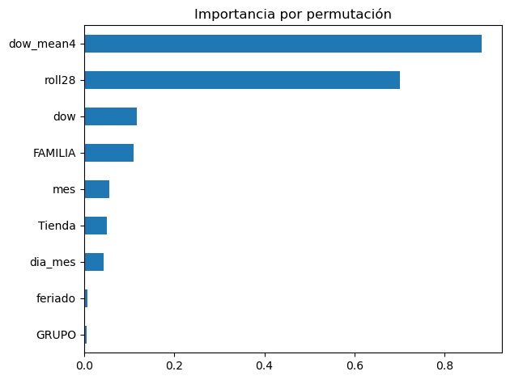

```
dow_mean4    0.8828
roll28       0.7013
dow          0.1179
FAMILIA      0.1106
mes          0.0557
Tienda       0.0500
dia_mes      0.0428
feriado      0.0082
GRUPO        0.0053
dtype: float64
```

```python
from sklearn.inspection import permutation_importance
samp = train.sample(min(20000, len(train)), random_state=1)
pi = permutation_importance(model, samp[FN + FC], samp['CANTIDAD'],
                            n_repeats=3, random_state=1, n_jobs=-1)
imp = pd.Series(pi.importances_mean, index=FN + FC).sort_values()
imp.plot(kind='barh', title='Importancia por permutación')
plt.tight_layout(); plt.show()
print(imp.sort_values(ascending=False).round(4))
```

**Lectura:** `dow_mean4` y `roll28` dominan por lejos — el modelo es, ante todo, un "promedio reciente inteligente". Después vienen `dow` y `FAMILIA`. `feriado` casi no pesa (hay poquísimos ejemplos para aprender). Moraleja de ingeniería de features: **el 80% del valor de un modelo de demanda está en representar bien el nivel reciente**; el algoritmo importa menos que los features.

## 8. Decisión final: modelo híbrido (reconciliación)

Cada modelo es mejor en el nivel de agregación que le importa a un proceso distinto del negocio: B en el reparto diario (producción/dotación), A en el total mensual por producto (compras). La práctica estándar en forecasting jerárquico es **reconciliar**: tomar los totales mensuales por producto del Modelo A y repartirlos entre los días según las proporciones del Modelo B.

`híbrido(producto, día) = total_mensual_A(producto) × [ pred_B(producto, día) / Σ_mes pred_B(producto) ]`

```python
def reconciliar(pred_b, pred_a):
    b = pred_b[['Tienda', 'CÓDIGO', 'FECHA', 'pred']].copy()
    b['mes'] = b['FECHA'].dt.month
    b['share_dia'] = (b.groupby(['Tienda', 'CÓDIGO', 'mes'])['pred']
                        .transform(lambda s: s / s.sum()))
    a = pred_a.copy(); a['mes'] = a['FECHA'].dt.month
    tot_a = (a.groupby(['Tienda', 'CÓDIGO', 'mes'])['pred'].sum()
               .rename('total_mes_a').reset_index())
    h = b.merge(tot_a, on=['Tienda', 'CÓDIGO', 'mes'], how='inner')
    h['pred'] = h['share_dia'] * h['total_mes_a']
    return h[['Tienda', 'CÓDIGO', 'FECHA', 'pred']].dropna()

ev_h = evaluar(reconciliar(pg, pa), 'Híbrido (total A × reparto B)')
```

```
Híbrido (total A × reparto B)  WMAPE sku-día 44.1% | tienda-día 12.7% | sku-mes 23.1% | sesgo -2.2%
```

**Conclusión del paso 4:** el GBM aporta valor real pero acotado sobre un baseline bien construido — la conclusión más frecuente (y más honesta) del ML aplicado a forecasting. El híbrido combina la fortaleza de cada uno y es el candidato para el presupuesto final.

**Próximo paso (notebook 05):** generar el presupuesto jul-dic 2026 con el modelo elegido — reentrenando con TODOS los datos hasta junio y base may-jun — y exportarlo al Excel final (una solapa por tienda, productos en filas × 157 días en columnas).